# MUSA 508 Assignment 1

Palak Agarwal & Shivani Rai

September 25th, 2020

# Introduction

This assignment looked at the **Bay Area Rapid Transit** and its analyzed all the 5 counties that it runs through to check if it has an effect on them. The main reason for choosing the BART system over the SF MTA system was to check if that cross county connection is more effective. SF being a big job center, attracts a lot of people from the surrounding counties in every day and the lack of vacancy and high housing values in the city forces people to stay in areas close to SF and commute everyday. The BART also connects other job centers in the bay area like San Jose, Oakland and the two airports.

## Load Themes

Create our mapping and plotting themes, color palettes and quantile break.

```r
mapTheme <- function(base_size = 12) {
  theme(
    text = element_text( color = "black"),
    plot.title = element_text(size = 24,colour = "black"),
    plot.subtitle=element_text(face="italic"),
    plot.caption=element_text(hjust=0),
    axis.ticks = element_blank(),
    panel.background = element_blank(),axis.title = element_blank(),
    axis.text = element_blank(),
    axis.title.x = element_blank(),
    axis.title.y = element_blank(),
    panel.grid.minor = element_blank(),
    panel.border = element_rect(colour = "black", fill=NA, size=2)
  )
}

plotTheme <- function(base_size = 12) {
  theme(
    text = element_text( color = "black"),
    plot.title = element_text(size = 24,colour = "black"),
    plot.subtitle = element_text(face="italic"),
    plot.caption = element_text(hjust=0),
    axis.ticks = element_blank(),
    panel.background = element_blank(),
    panel.grid.major = element_line("grey60", size = 0.1),
    panel.grid.minor = element_blank(),
    panel.border = element_rect(colour = "black", fill=NA, size=2),
    strip.background = element_rect(fill = "grey60", color = "white"),
    strip.text = element_text(size=12),
    axis.title = element_text(size=12),
    axis.text = element_text(size=10),
    plot.background = element_blank(),
    legend.background = element_blank(),
    legend.title = element_text(colour = "black", face = "italic"),
    legend.text = element_text(colour = "black", face = "italic"),
    strip.text.x = element_text(size = 14)
  )
}

# Load Quantile break functions

qBr <- function(df, variable, rnd) {
  if (missing(rnd)) {
    as.character(quantile(round(df[[variable]],0),
                          c(.01,.2,.4,.6,.8), na.rm=T))
  } else if (rnd == FALSE | rnd == F) {
    as.character(formatC(quantile(df[[variable]]), digits = 3),
                 c(.01,.2,.4,.6,.8), na.rm=T)
  }
}

q5 <- function(variable) {as.factor(ntile(variable, 5))}

# Load hexadecimal color palette

palette5 <- c("#f6d908","#d6c054","#878dac","#3574e2","#005fc4","#004b9a","#b2a681")
```

## Next lets load the data we going to use

```r
#data import - bart lines and crime data

sfo <- read.csv('C:/Users/agarw/Documents/MUSA508/MUSA-508-Assignment-1/Data/final_sfo_lines.csv')
```

## Loading the census API key

```r
census_api_key("aea3dee2d96acb5101e94f3dcfa1b575f73d093a", overwrite = TRUE)
```

## Data wrangling with census data

### Year 2009 and 2017

We use year 2009 and 2017 in this report for our analyzes. The **state code** for California is **6** and we pass the 5 counties we working with as a list in the county. The counties with their county codes are :  
* Alameda - 001  
* Contra Costa - 013  
* San Franscisco - 075  
* San Mateo - 081  
* Santa Clara - 085

```r
# ---- Year 2009 tracts -----

tracts09 <-
  get_acs(geography = "tract", variables = c("B25026_001E","B02001_002E","B19013_001E",
                                             "B25058_001E","B01001_006E","B01001_007E",
                                             "B01001_008E","B01001_009E","B01001_010E",
                                             "B01001_011E","B01001_012E","B01001_013E",
                                             "B01001_014E","B01001_015E","B01001_016E",
                                             "B01001_030E","B01001_031E","B01001_032E",
                                             "B01001_033E","B01001_034E","B01001_035E",
                                             "B01001_036E","B01001_037E","B01001_038E",
                                             "B01001_039E","B01001_040E","B12001_004E",
                                             "B12001_013E","B02001_003E","B02001_004E",
                                             "B02001_005E","B02001_006E","B03001_003E"),
          year=2009, state=06, county=c(001,075,081,013,085), geometry=T) %>%
  st_transform('ESRI:102241')

tracts09 <-
  tracts09 %>%
  dplyr::select( -NAME, -moe) %>%
  spread(variable, estimate) %>%
  dplyr::select(-geometry) %>%
  rename(TotalPop = B25026_001,
         Whites = B02001_002,
         Blacks = B02001_003,
         AmInd = B02001_004,
         Asian = B02001_005,
         Hawaiian = B02001_006,
         Hispanic = B03001_003,
         MedHHInc = B19013_001,
         MedRent = B25058_001,
         WorkingClassM1517 = B01001_006,
         WorkingClassM1819 = B01001_007,
         WorkingClassM20 = B01001_008,
         WorkingClassM21 = B01001_009,
         WorkingClassM2224 = B01001_010,
         WorkingClassM2529 = B01001_011,
         WorkingClassM3034 = B01001_012,
         WorkingClassM3539 = B01001_013,
         WorkingClassM4044 = B01001_014,
         WorkingClassM4549 = B01001_015,
         WorkingClassM5054 = B01001_016,
         WorkingClassF1517 = B01001_030,
         WorkingClassF1819 = B01001_031,
         WorkingClassF20 = B01001_032,
         WorkingClassF21 = B01001_033,
         WorkingClassF2224 = B01001_034,
         WorkingClassF2529 = B01001_035,
         WorkingClassF3034 = B01001_036,
         WorkingClassF3539 = B01001_037,
         WorkingClassF4044 = B01001_038,
         WorkingClassF4549 = B01001_039,
         WorkingClassF5054 = B01001_040,
         MaleMarried = B12001_004,
         FemaleMarried = B12001_013
         )

tracts209 <-
  tracts09 %>%
  mutate(pctWorking = ifelse(TotalPop > 0, ((WorkingClassM1517 + WorkingClassM1819
                                             + WorkingClassM20 + WorkingClassM21
                                             + WorkingClassM2224 + WorkingClassM2529
                                             + WorkingClassM3034 + WorkingClassM3539
                                             + WorkingClassM4044 + WorkingClassM4549
                                             + WorkingClassM5054 + WorkingClassF1517
                                             + WorkingClassF1819 + WorkingClassF20
                                             + WorkingClassF21   + WorkingClassF2224
                                             + WorkingClassF2529 + WorkingClassF3034
                                             + WorkingClassF3539 + WorkingClassF4044
                                             + WorkingClassF4549 + WorkingClassF5054)
                                            /TotalPop * 100), 0),
         pctMarried = ifelse(TotalPop > 0, ((FemaleMarried + MaleMarried) / TotalPop * 100), 0),
         pctWhite = ifelse(TotalPop > 0, Whites / TotalPop * 100, 0),
         pctOtherRace = ifelse(TotalPop > 0, ((Blacks + AmInd +Asian
                                               + Hawaiian + Hispanic) / TotalPop * 100), 0),

         year = "2009") %>%
  dplyr::select(-Whites,-FemaleMarried,-MaleMarried,-Blacks,-AmInd,-Asian,-Hawaiian,
                -Hispanic, -WorkingClassM1517,-WorkingClassM1819,-WorkingClassM20,
                -WorkingClassM21,-WorkingClassM2224,-WorkingClassM2529,
                -WorkingClassM3034,-WorkingClassM3539,-WorkingClassM4044,
                -WorkingClassM4549,-WorkingClassM5054,-WorkingClassF1517,
                -WorkingClassF1819,-WorkingClassF20,-WorkingClassF21,
                -WorkingClassF2224,-WorkingClassF2529,-WorkingClassF3034,
                -WorkingClassF3539,-WorkingClassF4044,-WorkingClassF4549,
                -WorkingClassF5054)

#----- Finding max values of popluation and rent to normalise the data
# as the tract is not truly representative of the data near the station------

maxtotpop_2009 <- max(tracts209$TotalPop)
maxrent_2009 <- max(tracts209$MedRent , na.rm = T)
tracts2009 <-
  tracts209 %>%
  mutate( normpop = TotalPop/maxtotpop_2009,
          normrent = MedRent/maxrent_2009)

# ---- Year 2017 tracts -----

tracts217 <-
  get_acs(geography = "tract", variables = c("B25026_001E","B02001_002E","B19013_001E",
                                             "B25058_001E","B01001_006E","B01001_007E",
                                             "B01001_008E","B01001_009E","B01001_010E",
                                             "B01001_011E","B01001_012E","B01001_013E",
                                             "B01001_014E","B01001_015E","B01001_016E",
                                             "B01001_030E","B01001_031E","B01001_032E",
                                             "B01001_033E","B01001_034E","B01001_035E",
                                             "B01001_036E","B01001_037E","B01001_038E",
                                             "B01001_039E","B01001_040E","B12001_004E",
                                             "B12001_013E","B02001_003E","B02001_004E",
                                             "B02001_005E","B02001_006E","B03001_003E"),
          year=2017, state=06, county=c(001,075,081,013,085), geometry=T) %>%
  st_transform('ESRI:102241') %>%
  dplyr::select( -NAME, -moe) %>%
  spread(variable, estimate) %>%
  dplyr::select(-geometry) %>%
  rename(TotalPop = B25026_001,
         Whites = B02001_002,
         Blacks = B02001_003,
         AmInd = B02001_004,
         Asian = B02001_005,
         Hawaiian = B02001_006,
         Hispanic = B03001_003,
         MedHHInc = B19013_001,
         MedRent = B25058_001,
         WorkingClassM1517 = B01001_006,
         WorkingClassM1819 = B01001_007,
         WorkingClassM20 = B01001_008,
         WorkingClassM21 = B01001_009,
         WorkingClassM2224 = B01001_010,
         WorkingClassM2529 = B01001_011,
         WorkingClassM3034 = B01001_012,
         WorkingClassM3539 = B01001_013,
         WorkingClassM4044 = B01001_014,
         WorkingClassM4549 = B01001_015,
         WorkingClassM5054 = B01001_016,
         WorkingClassF1517 = B01001_030,
         WorkingClassF1819 = B01001_031,
         WorkingClassF20 = B01001_032,
         WorkingClassF21 = B01001_033,
         WorkingClassF2224 = B01001_034,
         WorkingClassF2529 = B01001_035,
         WorkingClassF3034 = B01001_036,
         WorkingClassF3539 = B01001_037,
         WorkingClassF4044 = B01001_038,
         WorkingClassF4549 = B01001_039,
         WorkingClassF5054 = B01001_040,
         MaleMarried = B12001_004,
         FemaleMarried = B12001_013
  ) %>%
  mutate(pctWorking = ifelse(TotalPop > 0, ((WorkingClassM1517 + WorkingClassM1819
                                             + WorkingClassM20 + WorkingClassM21
                                             + WorkingClassM2224 + WorkingClassM2529
                                             + WorkingClassM3034 + WorkingClassM3539
                                             + WorkingClassM4044 + WorkingClassM4549
                                             + WorkingClassM5054 + WorkingClassF1517
                                             + WorkingClassF1819 + WorkingClassF20
                                             + WorkingClassF21   + WorkingClassF2224
                                             + WorkingClassF2529 + WorkingClassF3034
                                             + WorkingClassF3539 + WorkingClassF4044
                                             + WorkingClassF4549 + WorkingClassF5054)
                                            /TotalPop * 100), 0),
         pctMarried = ifelse(TotalPop > 0, ((FemaleMarried + MaleMarried) / TotalPop * 100), 0),
         pctWhite = ifelse(TotalPop > 0, Whites / TotalPop *100, 0),
         pctOtherRace = ifelse(TotalPop > 0, ((Blacks + AmInd +Asian
                                               + Hawaiian + Hispanic) / TotalPop * 100), 0),
         year = "2017") %>%
  dplyr::select(-Whites,-FemaleMarried,-MaleMarried,-Blacks,-AmInd,-Asian,-Hawaiian,
                -Hispanic,-WorkingClassM1517,-WorkingClassM1819,-WorkingClassM20,
                -WorkingClassM21,-WorkingClassM2224,-WorkingClassM2529,
                -WorkingClassM3034,-WorkingClassM3539,-WorkingClassM4044,
                -WorkingClassM4549,-WorkingClassM5054,-WorkingClassF1517,
                -WorkingClassF1819,-WorkingClassF20,-WorkingClassF21,-WorkingClassF2224,
                -WorkingClassF2529,-WorkingClassF3034,
                -WorkingClassF3539,-WorkingClassF4044,-WorkingClassF4549,-WorkingClassF5054)

#----- Finding max values of popluation and rent to normalise the data
# as the tract is not truly representative of the data near the station------

maxtotpop_2017 <- max(tracts217$TotalPop)
maxrent_2017 <- max(tracts217$MedRent , na.rm = T)
tracts2017 <-
  tracts217 %>%
  mutate( normpop = TotalPop/maxtotpop_2017,
          normrent = MedRent/maxrent_2017)
```

## Combing the year 2009 and 2017 tracts

```r
finalTract <- rbind(tracts2009,tracts2017)
```

## Data wrangling with BART data

The BART data we had was in a csv with no coordinate column hence we first separated that string value to get the X and Y for latitude and longitude on which the data could be plotted on the tract data.

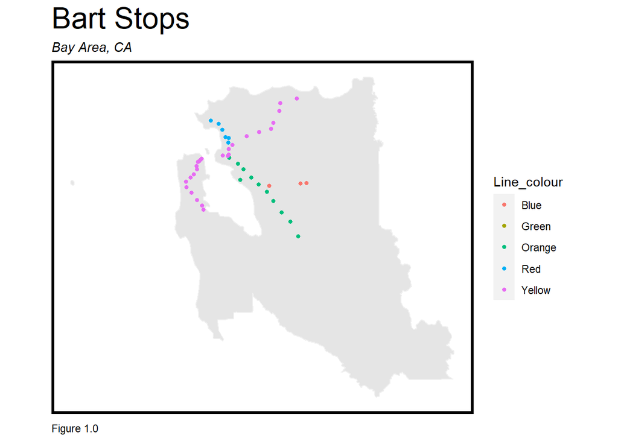

```r
x <- vector(mode='list', length = 105)
y <- vector(mode='list', length = 105)
spli <- strsplit(sfo$Location, ",")
for (val in spli){
  x <- append(x, val[[1]])
  y <- append(y, val[[2]])

}
sfo_new <-
  sfo %>%
  mutate(X = x[106:210],
         Y = y[106:210]) %>%
  dplyr::select(-Abbreviation, -Location, -Description)
crs_tract09 <- st_crs(tracts2009)
sfo_spatial <- st_as_sf(sfo_new, coords = c("X","Y"), crs = 4326, agr = "constant")
sfo_spatial <- sfo_spatial %>% st_transform(st_crs(tracts2009))

# Plotting the lines on the bay area tracts

ggplot() +
  geom_sf(data=st_union(tracts2009), colour = '#efefef') +
  geom_sf(data=sfo_spatial,
          aes(colour = Line_colour),
          show.legend = "point", size= 1.2) +
  labs(title="Bart Stops",
       subtitle="Bay Area, CA",
       caption="Figure 1.0") +
  mapTheme()
```

## Creating the buffer zone

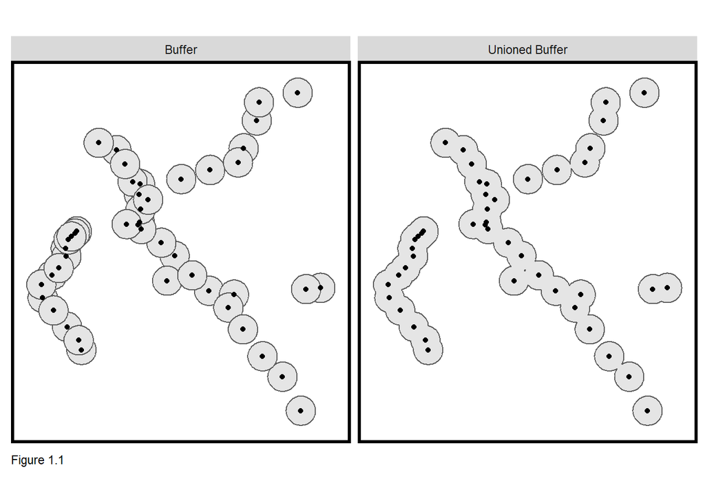

```r
# Both a buffer for each stop, and a union of the buffers...
# and bind these objects together

bartBuffers <-
  rbind(
    st_buffer(sfo_spatial, 2640) %>%
      mutate(Legend = "Buffer") %>%
      dplyr::select(Legend),
    st_union(st_buffer(sfo_spatial, 2640)) %>%
      st_sf() %>%
      mutate(Legend = "Unioned Buffer"))

# Let's examine both buffers by making a small multiple
# "facet_wrap" plot showing each

ggplot() +
  geom_sf(data=bartBuffers) +
  geom_sf(data=sfo_spatial, show.legend = "point") +
  facet_wrap(~Legend) +
  labs(caption = "Figure 1.1") +
  mapTheme()
```

## Finding tracts which lie within the buffer zone

To do this, we clip the union buffer with the tracts, and find the tracts within this intersection. As we do not have the census distribution within the tracts, will we know not which attribute of the census belongs within 0.5 mile radius of each transit station. So to over come this challenge with data, we assume that if the centroid of the census tract lies within the buffer zone, its attributes will be significant.

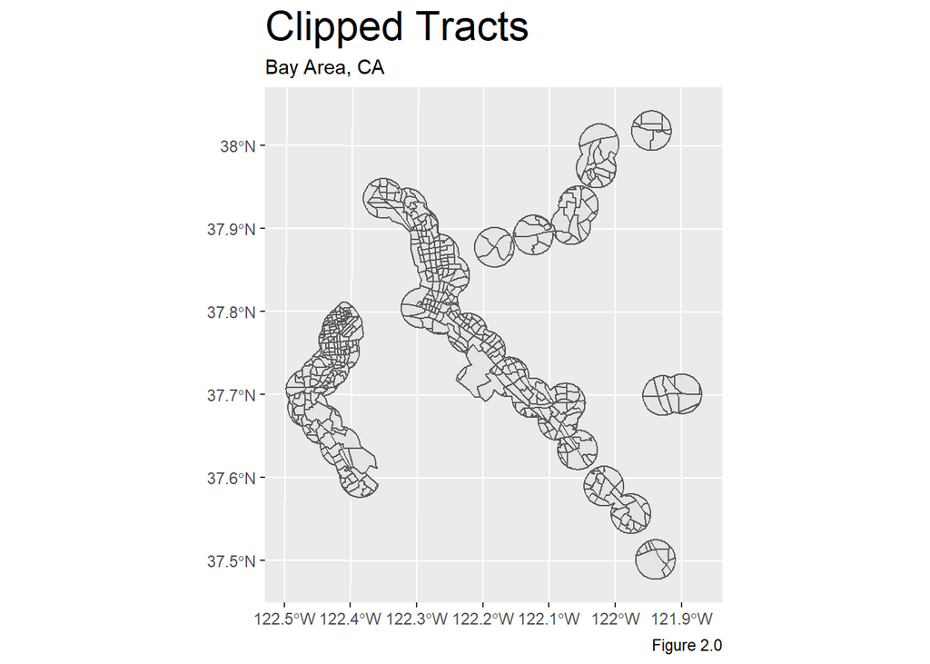

```r
# Create an sf object with ONLY the unioned buffer
buffer <- filter(bartBuffers, Legend=="Unioned Buffer")

# Clip the 2009 tracts ... by seeing which tracts intersect (st_intersection)
# with the buffer and clipping out only those areas
clip <-
  st_intersection(buffer, tracts2009) %>%
  dplyr::select(TotalPop) %>%
  mutate(Selection_Type = "Clip")

ggplot() +
  geom_sf(data = clip) +
  labs(title="Clipped Tracts",
         subtitle="Bay Area, CA",
         caption="Figure 2.0") +
  theme(plot.title = element_text(size=22))
```

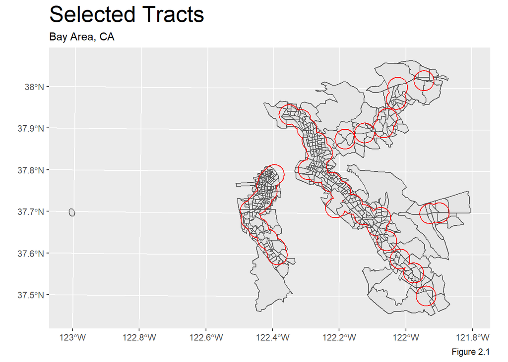

```r
# Do a spatial selection to see which tracts touch the buffer
selection <-
  tracts2009[buffer,] %>%
  dplyr::select(TotalPop) %>%
  mutate(Selection_Type = "Spatial Selection")

ggplot() +
  geom_sf(data = selection) +
  geom_sf(data = buffer, fill = "transparent", color = "red")+
  labs(title="Selected Tracts",
         subtitle="Bay Area, CA",
         caption="Figure 2.1") +
  theme(plot.title = element_text(size=22))
```

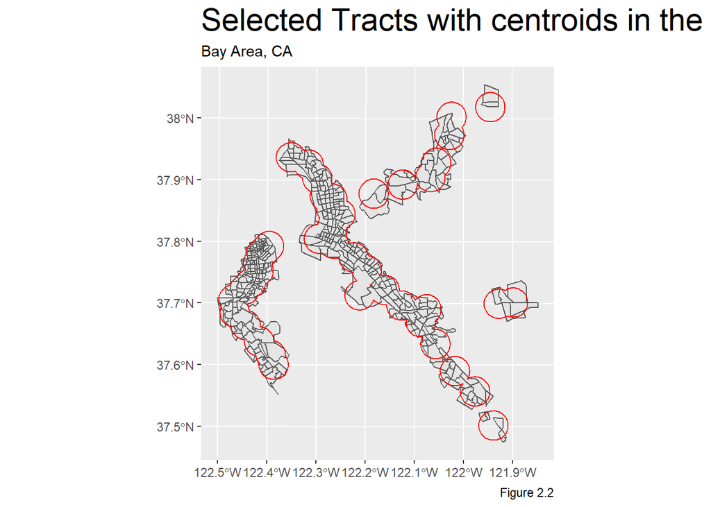

```r
# Do a centroid-in-polygon join to see which tracts have their centroid in the buffer
# Note the st_centroid call creating centroids for each feature
selectCentroids <-
  st_centroid(tracts2009)[buffer,] %>%
  st_drop_geometry() %>%
  left_join(dplyr::select(tracts2009, GEOID)) %>%
  st_sf() %>%
  dplyr::select(TotalPop) %>%
  mutate(Selection_Type = "Select by Centroids")

ggplot() +
  geom_sf(data = selectCentroids) +
  geom_sf(data = buffer, fill = "transparent", color = "red")+
  labs(title="Selected Tracts with centroids in the buffer zone",
       subtitle="Bay Area, CA",
       caption="Figure 2.2") +
  theme(plot.title = element_text(size=22))
```

## Classifying tract as TOD and Non-TOD

Now that we have found the tracts whose centroids that fall within the buffer zone, lets classify those tracts as **TOD** - transit oriented development and **Non-TOD**.

```r
# We do our centroid joins as above, and then do a "disjoin" to get the ones that *don't*
# join, and add them all together and add a new column TOD.
# Note that this contains a correct 2009-2017 inflation calculation

finalTract.group <-
  rbind(
    st_centroid(finalTract)[buffer,] %>%
      st_drop_geometry() %>%
      left_join(finalTract) %>%
      st_sf() %>%
      mutate(TOD = "TOD"),
    st_centroid(finalTract)[buffer, op = st_disjoint] %>%
      st_drop_geometry() %>%
      left_join(finalTract) %>%
      st_sf() %>%
      mutate(TOD = "Non-TOD")) %>%
  mutate(MedRent.inf = ifelse(year == "2009", MedRent * 1.14, MedRent))
```

## TOD Indicators

According to BART’s ridership reports, its ridership increased by **16.2%** from 2009 to 2017. Also the increase is noticed in the far off counties like Alameda and Santa Clara. So the BART system seems to be fulfilling its purpose of connecting different counties. This would mean that the planning and construction of BART would have attracted development in the different counties and towns it goes through. To check this hypothesis, we analyses the following criterias which we think could have affected the ridership and development in the TOD zones. The four indicators we think important are :  
* Rent  
* Percentage of married people  
* Racial Composition  
* Percentage of Working class

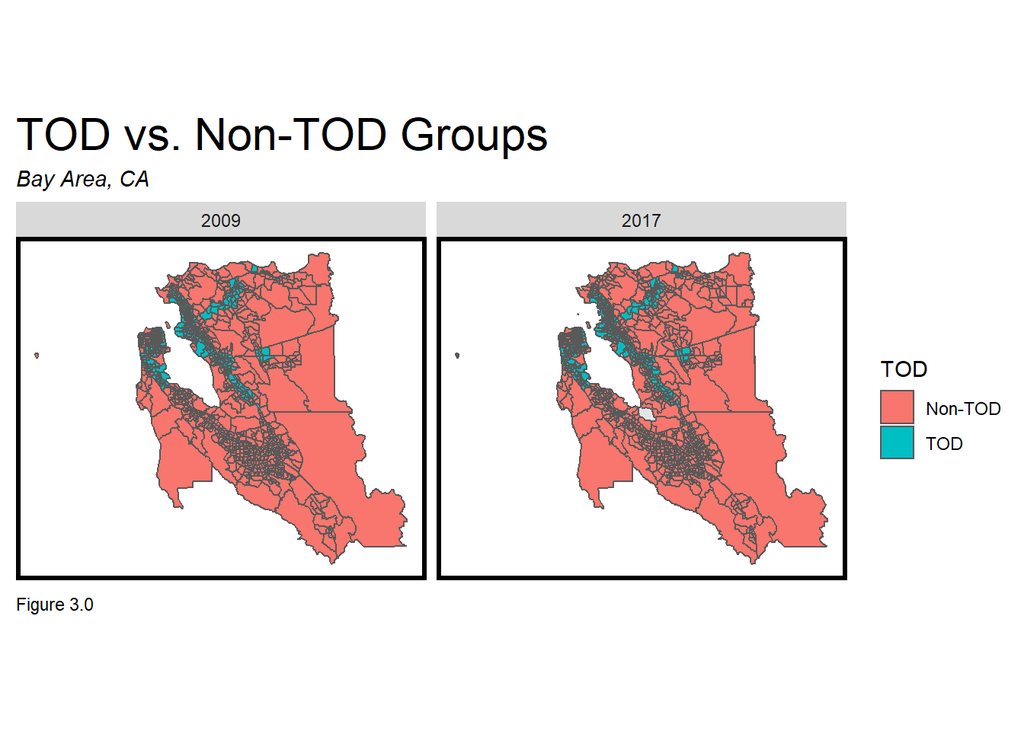

```r
#----- Plot which are the TOD tracts

ggplot(finalTract.group)+
  geom_sf(data = st_union(tracts2009))+
  geom_sf(aes(fill = TOD)) +
  labs(title = "TOD vs. Non-TOD Groups",
       subtitle="Bay Area, CA",
       caption="Figure 3.0") +
  facet_wrap(~year)+
  mapTheme() +
  theme(plot.title = element_text(size=22))
```

Lets discuss each indicator and its affect on TOD.

### Rent

The main purpose of transit oriented development is to attract and increase density in certain parts of the city. By having amenities and housing around transit, the system becomes more efficient due to increased foot fall. It also allows for land value capitalization, which is essential to both developers and governments. Renters and home buyers are usually more happy paying to locate near transit amenities which should be reflected in higher land values and property tax returns near stations.  
Now lets visualize rent as a function of time and space.

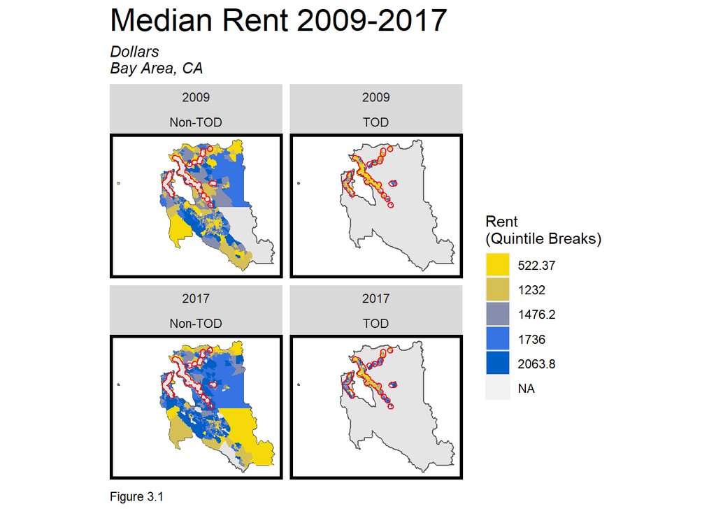

```r
#----- Plot rent as a function of year and TOD

ggplot(finalTract.group)+
  geom_sf(data = st_union(tracts2009))+
  geom_sf(aes(fill = q5(MedRent.inf)), color = "transparent") +
  geom_sf(data = buffer, fill = "transparent", color = "red", size = 0.5)+
  scale_fill_manual(values = palette5,
                    labels = qBr(finalTract.group, "MedRent.inf"),
                    name = "Rent\n(Quintile Breaks)") +
  labs(title = "Median Rent 2009-2017", subtitle = "Dollars\nBay Area, CA", caption="Figure 3.1") +
  facet_wrap(~year + TOD)+
  mapTheme() +
  theme(plot.title = element_text(size=22))
```

As it is evident in the map, most tracts in San Mateo, San Francisco, Contra Costa and Santa Clara saw an increase in rent from year 2009 to 2017 while Alameda remained stagnant. Other interesting observation is that tracts close to the transit line but not in the buffer zone saw a large increase in rent values. The transit stops are connected through bus and biking networks as extra infrastructure, we could have affected the other tracts to develop as well.

### Percentage of Married people

Our hypothesis is that a lot of families move out of the city to the suburbs to have more space and to raise families.Cities can get congested and finding home big enough to raise a family can get more expensive if one chooses to live in the downtown areas. Most familes have only two options- to move to neighborhoods outside the main district or to move out of the city and commute everyday. What ever the choice might be they would still prefer to be able have easy access to the city as it forms a major job hub. So it is fair to assume that they would prefer to stay around the transit to avoid everyday driving and parking hassle.

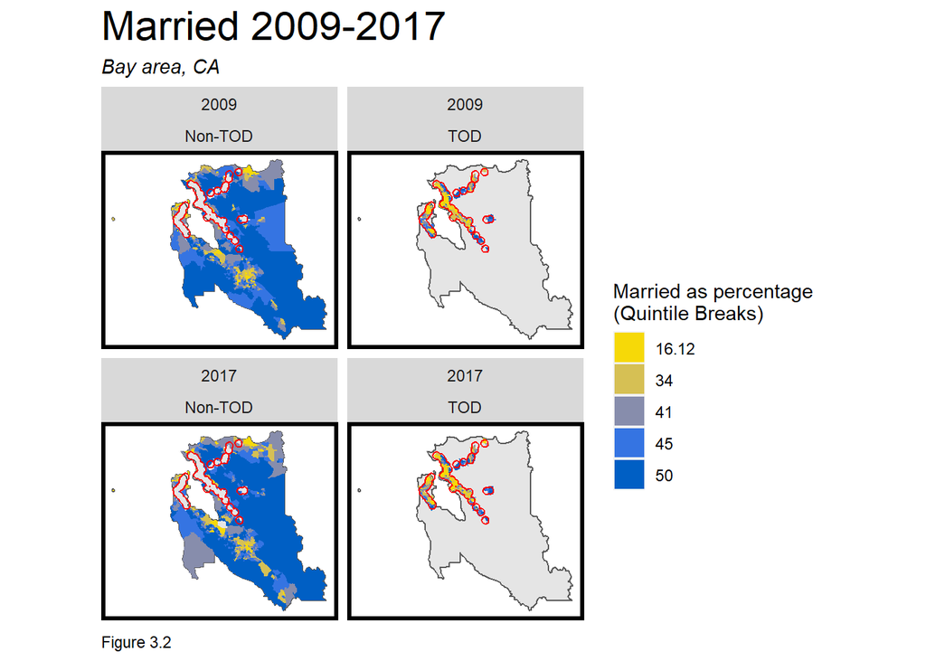

```r
#-----Plotted number of married people in the tract as function of year and TOD

ggplot(finalTract.group)+
  geom_sf(data = st_union(tracts2009))+
  geom_sf(aes(fill = q5(pctMarried)), color = "transparent") +
  geom_sf(data = buffer, fill = "transparent", color = "red")+
  scale_fill_manual(values = palette5,
                    labels = qBr(finalTract.group, "pctMarried"),
                    name = "Married as percentage \n(Quintile Breaks)") +
  labs(title = "Married 2009-2017", subtitle = "Bay area, CA", caption="Figure 3.2") +
  facet_wrap(~year + TOD)+
  mapTheme() +
  theme(plot.title = element_text(size=22))
```

From the plots, we can see that Contra Costa has seen in an increase in the percentage of married couples while other TOD tracts have remained stagnant or seen a decrease. If you notice the tracts outside the 0.5 mile radius, we see that the percentage of married couples has increased slightly and this could mean that they might or might not use BART to travel for work or even leisurely. It can also be that the families have moved away from the buffer zone as a result of increased density around them which was the initial reason to move out of the city.

### Racial Composition

The Bay area has a large proportion of immigration populations. Being the Silicon Valley, a lot of immigrants move in the area because of the jobs created by the IT industry. We want to check if transit is an amenity that is seeked by certain groups while searching for housing.

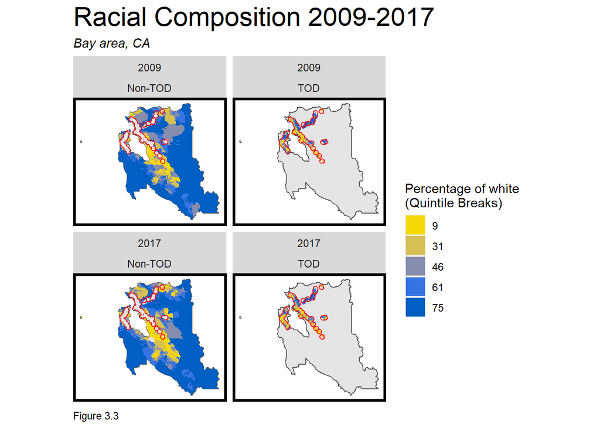

```r
#-----Plotted number racial composition in the tract as function of year and TOD

ggplot(finalTract.group)+
  geom_sf(data = st_union(tracts2009))+
  geom_sf(aes(fill = q5(pctWhite)), color = "transparent") +
  geom_sf(data = buffer, fill = "transparent", color = "red")+
  scale_fill_manual(values = palette5,
                    labels = qBr(finalTract.group, "pctWhite"),
                    name = "Percentage of white \n(Quintile Breaks)") +
  labs(title = "Racial Composition 2009-2017", subtitle = "Bay area, CA", caption="Figure 3.3") +
  facet_wrap(~year + TOD)+
  mapTheme() +
  theme(plot.title = element_text(size=22))
```

From the plots, we can see that the percentage of white people near the transit have reduced which would mean that it is filled by other racial groups. That is the over all trend even outside the buffer zone. Many factors can have caused this change in racial composition, but one important one is job creation and the groups those jobs attract. Close to 40% of the population in the Bay area is made out of immigrant groups that include large portions of Asians and Hispanics.

### Percentage of working class

As mentioned already, BART connects major job centers like San Franscisco, Oakland, San Jose and the two airports. So its only fair to hypothesize that working class would prefer to find housing in and around transit for easy commuting. For this map, we considered a percentage of population who are in the age groups of 16-54 as the population most likely to form the working class and to commute everyday for work.

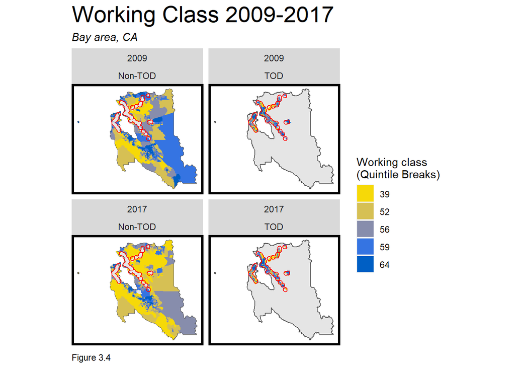

```r
#-----Plotted number the number of people in the working industry in the tract as function of year and TOD

ggplot(finalTract.group)+
  geom_sf(data = st_union(tracts2009))+
  geom_sf(aes(fill = q5(pctWorking)), color = "transparent") +
  geom_sf(data = buffer, fill = "transparent", color = "red")+
  scale_fill_manual(values = palette5,
                    labels = qBr(finalTract.group, "pctWorking"),
                    name = "Working class \n(Quintile Breaks)") +
  labs(title = "Working Class 2009-2017", subtitle = "Bay area, CA", caption="Figure 3.4") +
  facet_wrap(~year + TOD)+
  mapTheme() +
  theme(plot.title = element_text(size=22))
```

## Bar Plot

Now that we have seen these individual plots above, lets plot all the variables in a grouped bar plot to see all the data at once.

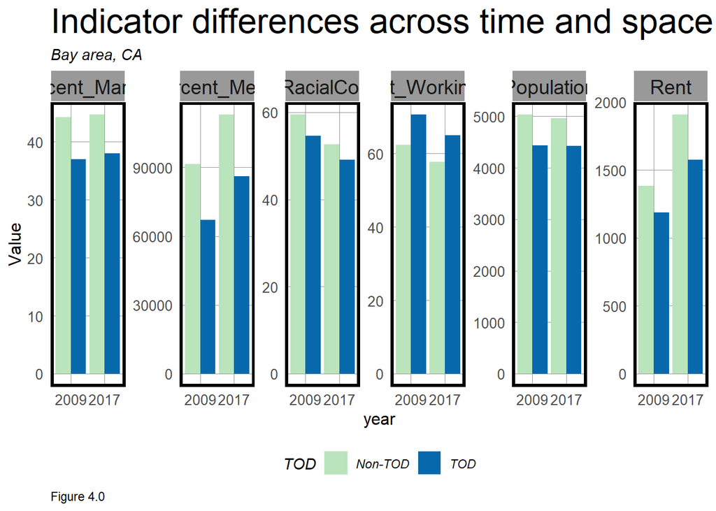

```r
#---- Finding the mean of the variables

finalTract.Summary <-
  st_drop_geometry(finalTract.group) %>%
  group_by(year, TOD) %>%
  summarize(Rent = mean(MedRent, na.rm = T),
            Population = mean(TotalPop, na.rm = T),
            Percent_RacialComposition= mean(pctWhite, na.rm = T),
            Percent_WorkingClass= mean(pctWorking, na.rm = T),
            Percent_Married = mean(pctMarried, na.rm = T),
            Percent_MedIn = mean(MedHHInc, na.rm = T))

#Bar plot
finalTract.Summary %>%
  gather(Variable, Value, -year, -TOD) %>%
  ggplot(aes(year, Value, fill = TOD)) +
  geom_bar(stat = "identity", position = "dodge") +
  facet_wrap(~Variable, scales = "free", nrow=1) +
  scale_fill_manual(values = c("#bae4bc", "#0868ac")) +
  labs(title = "Indicator differences across time and space", subtitle = "Bay area, CA", caption="Figure 4.0") +
  plotTheme() + theme(legend.position="bottom")
```

## Table

```r
#table
kable(finalTract.Summary) %>%
  kable_styling() %>%
  footnote(general_title = "\n",
           general = "Table 1.0")
```

| year | TOD | Rent | Population | Percent_RacialComposition | Percent_WorkingClass | Percent_Married | Percent_MedIn |
| --- | --- | --- | --- | --- | --- | --- | --- |
| 2009 | Non-TOD | 1384.605 | 5035.554 | 59.49284 | 62.28016 | 44.30454 | 91574.79 |
| 2009 | TOD | 1185.980 | 4432.152 | 54.59128 | 70.60366 | 36.97445 | 67193.76 |
| 2017 | Non-TOD | 1908.333 | 4961.282 | 52.60062 | 57.66027 | 44.72019 | 113062.73 |
| 2017 | TOD | 1575.719 | 4421.412 | 49.06128 | 64.89203 | 37.98244 | 86183.12 |

Table 1.0

## Graduated symbol maps

```r
# Create an sf object with ONLY the buffers
buffers <- filter(bartBuffers, Legend=="Buffer")
buffer_spatial <- buffers %>% st_transform(st_crs(tracts2009))

x <- vector(mode='list', length = 105)
y <- vector(mode='list', length = 105)

for( val in c(1:105))
{
  #print(buffer_spatial[[val,2]])
  clip1 <-
    st_intersection(buffer_spatial[val,1], tracts2009) %>%
    dplyr::select(normpop,normrent) %>%
    mutate(Selection_Type = "Clip")
  selection1 <-
    tracts2009[buffer_spatial[val,1],] %>%
    dplyr::select(normpop,normrent) %>%
    mutate(Selection_Type = "Spatial Selection")
  selectCentroids1 <-
    st_centroid(tracts2009)[buffer_spatial[val,1],] %>%
    st_drop_geometry() %>%
    left_join(dplyr::select(tracts2009, GEOID)) %>%
    st_sf() %>%
    dplyr::select(normpop,normrent) %>%
    mutate(Selection_Type = "Select by Centroids")
  sum_sb <- max(selectCentroids1$normpop)
  sum_sc <- max(selectCentroids1$normrent)
  x <- append(x, sum_sb)
  y <- append(y, sum_sc)
}

pograd <- sfo_spatial %>%
  mutate(Sum_Popnor = as.numeric(x[106:210]),
         Sum_Rentnor = as.numeric(y[106:210]))
popgrad <- pograd %>%
  mutate(Sum_Popnorm = Sum_Popnor * 100,
         Sum_Rentnorm = Sum_Rentnor * 100)
```

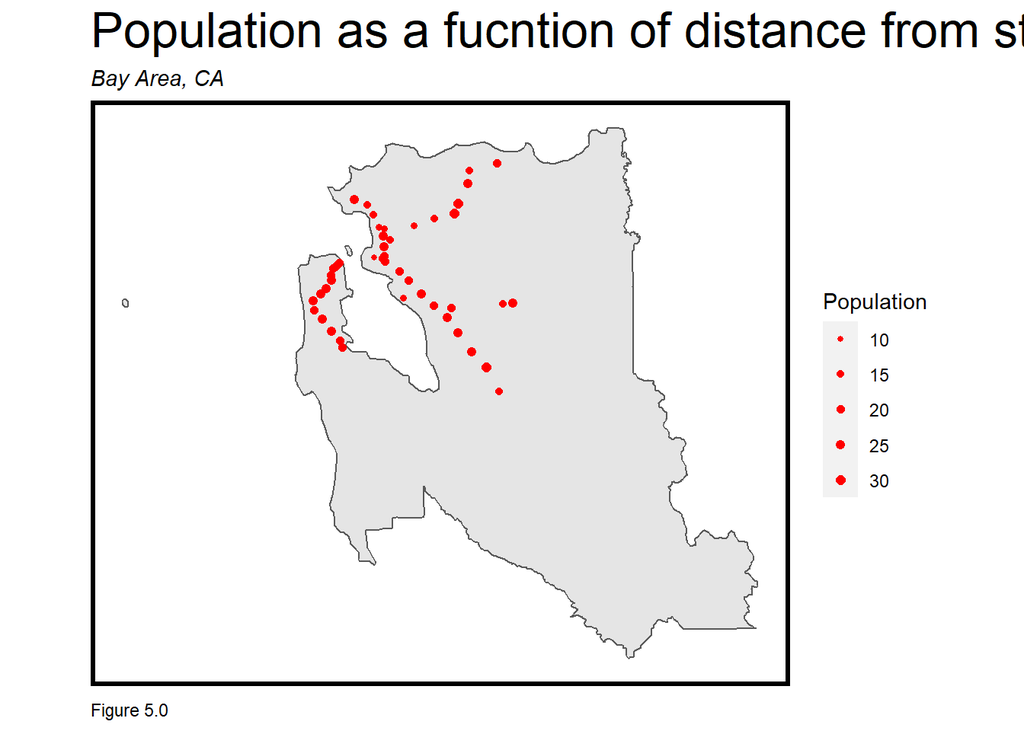

```r
#Population
ggplot()+
  geom_sf(data = st_union(tracts2009))+
  geom_sf(data=popgrad,
          aes(size = Sum_Popnorm),
          color = "red")+
  scale_size_area(name="", max_size = 2.0) +
  guides(size=guide_legend("Population")) +
  labs(
    title = "Population as a fucntion of distance from stops",
    subtitle = "Bay Area, CA",
    caption = "Figure 5.0"
  )+
  mapTheme()
```

[figure not shown]

```r
#Rent
ggplot()+
  geom_sf(data = st_union(tracts2009))+
  geom_sf(data=popgrad,
          aes(size = Sum_Rentnorm),
          color = "red")+
  scale_size_area(name="", max_size = 2.0) +
  guides(size=guide_legend("Total Venues")) +
  labs(
    title = "Rent as a fucntion of distance from stops",
    subtitle = "Bay Area, CA",
    caption = "Figure 5.1"
  )+
  mapTheme()
```

As expected, rents and population is high in the downtown regions of SF. It is the most sought after real estate in the US and that accounts for this high occupancy and land value. After that, downtown of Oakland has the next highest rents and population. The rest of the counties have very similar rent and population relationship. It is interesting to see that the job hubs still have that high of an occupancy even though cheaper and vacant counties are connected to it through a rapid public transit system. This could mean that that the BART isn’t as efficient and accessible as it was planned or that a large portion of people still prefer to stay very close to their place of work.

## Rent as a function of distance to transit stops

Lets look at how rent changes as we move further away from the station. Notice the sudden drop in rent after 6 miles from the transit stop which is even large in the year 2017.

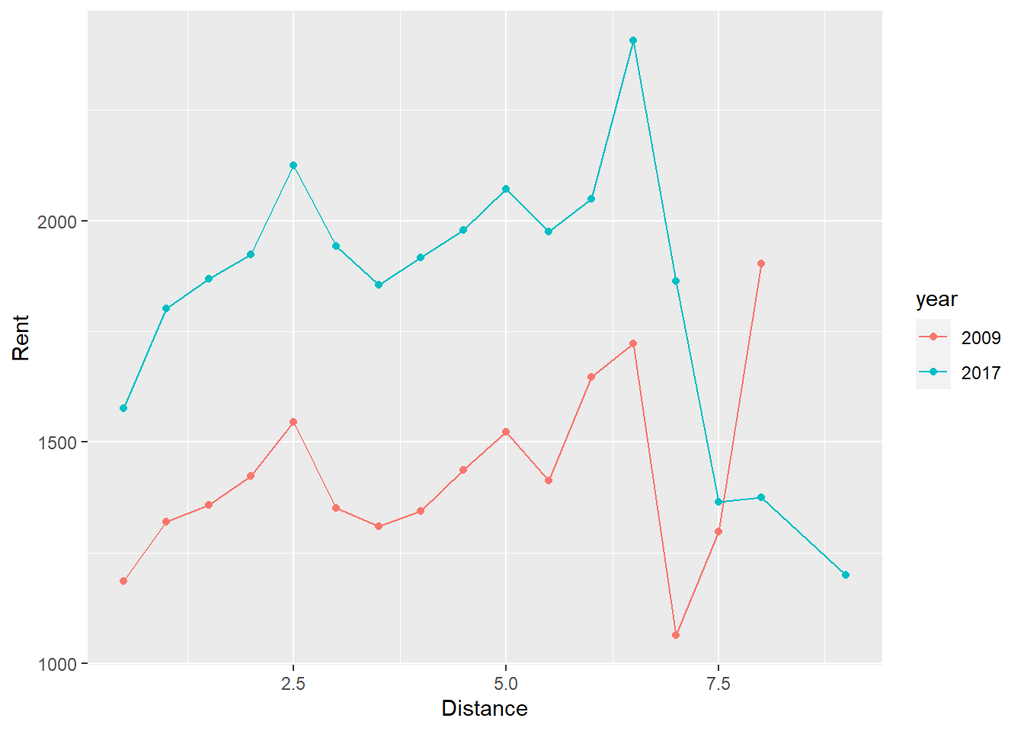

```r
#Function MultipleRingBuffer
multipleRingBuffer <- function(inputPolygon, maxDistance, interval)
{
  #create a list of distances that we'll iterate through to create each ring
  distances <- seq(0, maxDistance, interval)
  #we'll start with the second value in that list - the first is '0'
  distancesCounter <- 2
  #total number of rings we're going to create
  numberOfRings <- floor(maxDistance / interval)
  #a counter of number of rings
  numberOfRingsCounter <- 1
  #initialize an otuput data frame (that is not an sf)
  allRings <- data.frame()

  #while number of rings  counteris less than the specified nubmer of rings
  while (numberOfRingsCounter <= numberOfRings)
  {
    #if we're interested in a negative buffer and this is the first buffer
    #(ie. not distance = '0' in the distances list)
    if(distances[distancesCounter] < 0 & distancesCounter == 2)
    {
      #buffer the input by the first distance
      buffer1 <- st_buffer(inputPolygon, distances[distancesCounter])
      #different that buffer from the input polygon to get the first ring
      buffer1_ <- st_difference(inputPolygon, buffer1)
      #cast this sf as a polygon geometry type
      thisRing <- st_cast(buffer1_, "POLYGON")
      #take the last column which is 'geometry'
      thisRing <- as.data.frame(thisRing[,ncol(thisRing)])
      #add a new field, 'distance' so we know how far the distance is for a give ring
      thisRing$distance <- distances[distancesCounter]
    }


    #otherwise, if this is the second or more ring (and a negative buffer)
    else if(distances[distancesCounter] < 0 & distancesCounter > 2)
    {
      #buffer by a specific distance
      buffer1 <- st_buffer(inputPolygon, distances[distancesCounter])
      #create the next smallest buffer
      buffer2 <- st_buffer(inputPolygon, distances[distancesCounter-1])
      #This can then be used to difference out a buffer running from 660 to 1320
      #This works because differencing 1320ft by 660ft = a buffer between 660 & 1320.
      #bc the area after 660ft in buffer2 = NA.
      thisRing <- st_difference(buffer2,buffer1)
      #cast as apolygon
      thisRing <- st_cast(thisRing, "POLYGON")
      #get the last field
      thisRing <- as.data.frame(thisRing$geometry)
      #create the distance field
      thisRing$distance <- distances[distancesCounter]
    }

    #Otherwise, if its a positive buffer
    else
    {
      #Create a positive buffer
      buffer1 <- st_buffer(inputPolygon, distances[distancesCounter])
      #create a positive buffer that is one distance smaller. So if its the first buffer
      #distance, buffer1_ will = 0.
      buffer1_ <- st_buffer(inputPolygon, distances[distancesCounter-1])
      #difference the two buffers
      thisRing <- st_difference(buffer1,buffer1_)
      #cast as a polygon
      thisRing <- st_cast(thisRing, "POLYGON")
      #geometry column as a data frame
      thisRing <- as.data.frame(thisRing[,ncol(thisRing)])
      #add teh distance
      thisRing$distance <- distances[distancesCounter]
    }

    #rbind this ring to the rest of the rings
    allRings <- rbind(allRings, thisRing)
    #iterate the distance counter
    distancesCounter <- distancesCounter + 1
    #iterate the number of rings counter
    numberOfRingsCounter <- numberOfRingsCounter + 1
  }

  #convert the allRings data frame to an sf data frame
  allRings <- st_as_sf(allRings)
}

#Creating the buffer around the transit stops
finalTracts.rings <-
  st_join(st_centroid(dplyr::select(finalTract, GEOID, year)),
          multipleRingBuffer(st_union(sfo_spatial), 47520, 2640)) %>%
  st_drop_geometry() %>%
  left_join(dplyr::select(finalTract, GEOID, MedRent, year),
            by=c("GEOID"="GEOID", "year"="year")) %>%
  st_sf() %>%
  mutate(Distance = distance / 5280) #convert to miles

#Finding the mean of rent within the same distance
finalTracts.rings_summary <-
  finalTracts.rings %>%
  st_drop_geometry() %>%
  group_by(Distance, year) %>%
  summarize(Rent = mean(MedRent, na.rm=T))

#Plotting the data
ggplot(data=finalTracts.rings_summary,
       aes(x = Distance, y = Rent, colour = year)) +
  geom_line()+
  geom_point()
```